# Exploring Global Economic and Social Indicators in G20 Countries (Python)

IY1 Computer Science Sep 24 Cohort

2025-02-28

# Introduction

The **G20** (Group of Twenty) is an international forum comprising 19 countries plus the European Union. It represents the world’s major advanced and emerging economies. In this project, we explore various economic and social indicators of G20 countries using Python. We will work with a dataset containing information on GDP, HDI, population, and more.

# Overview of the Dataset

The dataset (file: `G_20_Data_CN.csv`) contains the following columns:

- **Country:** Name of the country (or union) within the G20.
- **Trad_bill_USD:** Traditional bill in USD (an economic indicator).
- **Nom_GDP_mill:** Nominal GDP in million USD.
- **PPP_GDP_mill_USD:** GDP (Purchasing Power Parity) in million USD.
- **Nom_GDP_Per_capita:** Nominal GDP per capita.
- **PPP_GDP_PerCapita:** GDP per capita at purchasing power parity.
- **HDI:** Human Development Index.
- **Population:** Total population.
- **Area (km²):** Geographic area.
- **IMF Classification:** Classification by the IMF (e.g., Advanced, Emerging).
- **Capital:** The capital city.
- **Region:** Geographic region.

# Project Tasks

Students are required to:

1. **Data Preparation and Cleaning:**
   - Load the CSV data using Python.
   - Clean numeric columns (e.g., remove commas and convert to numeric).
   - Set the “Country” column as the index.
2. **Adding a New Variable:**
   - Create a new variable classifying countries as “English Speaker” or “Non-English Speaker” based on a given list.
3. **Descriptive Statistics and Visualization:**
   - Generate descriptive statistics.
   - Create visualizations (histograms, box plots) to explore relationships in the data.
4. **Research Questions:**
   - Define one or more research questions (e.g., differences in GDP per capita between English-speaking and non-English-speaking countries).
   - Answer these questions using appropriate analysis techniques.

# Python Code Implementation

Below are the Python code chunks that perform each of the steps.

## 1. Load and Clean the Data

```python
import pandas as pd

# Specify the full file path to the CSV file.


file_path = r"C:\Users\Arash\OneDrive - Royal Holloway University of London\Desktop\RH\Python\Assignments\24_25\G_20\G_20_Data_CN.csv"

# Read the CSV file (using 'latin1' encoding if needed)
df = pd.read_csv(file_path, encoding="latin1")
print("Initial Data:")
```

```
## Initial Data:
```

```python
print(df.head())
```

```
##      Country Trad_bill_USD  ...     Capital.1       Region.1
## 0  Argentina         170.1  ...  Buenos Aires  South America
## 1  Australia         721.4  ...      Canberra        Oceania
## 2     Brazil         626.4  ...     BrasÃlia  South America
## 3     Canada      1,179.10  ...        Ottawa  North America
## 4      China      6,309.60  ...       Beijing           Asia
##
## [5 rows x 15 columns]
```

```python
# Remove commas from numeric columns and convert them
for col in df.select_dtypes(include='object').columns:
    df[col] = df[col].str.replace(",", "", regex=True)
    df[col] = pd.to_numeric(df[col], errors='ignore')

print("\nCleaned Data:")
```

```
##
## Cleaned Data:
```

```python
print(df.head())
```

```
##      Country  Trad_bill_USD  ...     Capital.1       Region.1
## 0  Argentina          170.1  ...  Buenos Aires  South America
## 1  Australia          721.4  ...      Canberra        Oceania
## 2     Brazil          626.4  ...     BrasÃlia  South America
## 3     Canada         1179.1  ...        Ottawa  North America
## 4      China         6309.6  ...       Beijing           Asia
##
## [5 rows x 15 columns]
```

## 2. Set “Country” as the Index

```python
# Set the "Country" column as the index
df.set_index("Country", inplace=True)
print("\nData with 'Country' as the Index:")
```

```
##
## Data with 'Country' as the Index:
```

```python
print(df.head())
```

```
##            Trad_bill_USD  Nom_GDP_mill  ...     Capital.1       Region.1
## Country                                 ...
## Argentina          170.1        604382  ...  Buenos Aires  South America
## Australia          721.4       1802006  ...      Canberra        Oceania
## Brazil             626.4       2188419  ...     BrasÃlia  South America
## Canada            1179.1       2214796  ...        Ottawa  North America
## China             6309.6      18273357  ...       Beijing           Asia
##
## [5 rows x 14 columns]
```

## 3. Add a New Variable: English Speaker Classification

```python
# Define a list of predominantly English-speaking countries
english_speakers = ["Australia", "Canada", "United Kingdom", "United States"]

# Create a new column 'English_Speaker' based on the index
df["English_Speaker"] = df.index.isin(english_speakers)
print("\nData with 'English_Speaker' column added:")
```

```
##
## Data with 'English_Speaker' column added:
```

```python
print(df.head())
```

```
##            Trad_bill_USD  Nom_GDP_mill  ...       Region.1  English_Speaker
## Country                                 ...
## Argentina          170.1        604382  ...  South America            False
## Australia          721.4       1802006  ...        Oceania             True
## Brazil             626.4       2188419  ...  South America            False
## Canada            1179.1       2214796  ...  North America             True
## China             6309.6      18273357  ...           Asia            False
##
## [5 rows x 15 columns]
```

## 4. Descriptive Statistics and Visualization

### Descriptive Statistics

```python
# Display summary statistics for numeric columns
print("\nDescriptive Statistics:")
```

```
##
## Descriptive Statistics:
```

```python
print(df.describe())
```

```
##        Trad_bill_USD  Nom_GDP_mill  ...    Population    Area (km²)
## count      21.000000  2.100000e+01  ...  2.100000e+01  2.100000e+01
## mean     1774.542857  5.161663e+06  ...  3.106438e+08  5.380341e+06
## std      1832.827101  7.489989e+06  ...  4.701033e+08  7.250720e+06
## min       170.100000  4.030450e+05  ...  2.614137e+07  1.002100e+05
## 25%       626.400000  1.802006e+06  ...  6.106000e+07  6.406790e+05
## 50%      1204.500000  2.214796e+06  ...  8.555193e+07  2.149690e+06
## 75%      1435.800000  3.889130e+06  ...  2.790889e+08  8.515767e+06
## max      6309.600000  2.916778e+07  ...  1.411750e+09  2.992206e+07
##
## [8 rows x 8 columns]
```

### Histogram: Nominal GDP per Capita

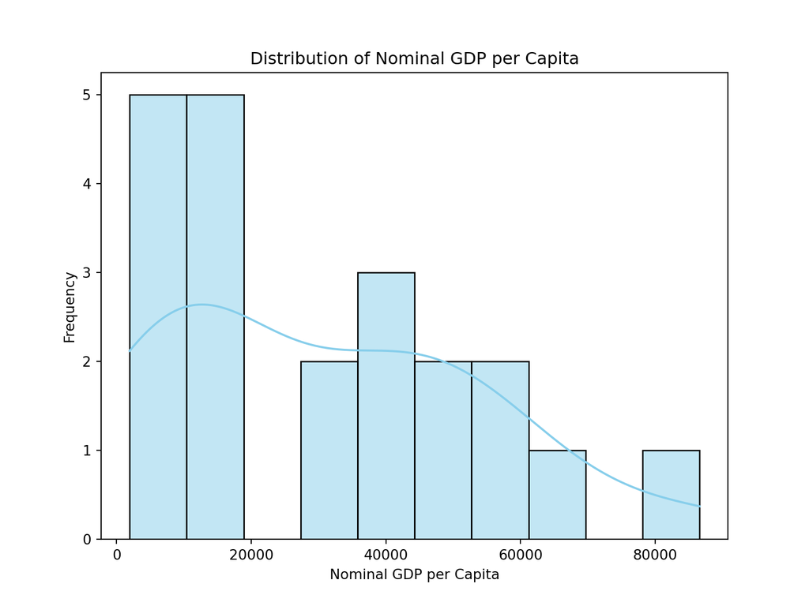

```python
import matplotlib.pyplot as plt
import seaborn as sns

plt.figure(figsize=(8,6))
sns.histplot(df["Nom_GDP_Per_capita"].dropna(), bins=10, kde=True, color="skyblue", edgecolor="black")
plt.title("Distribution of Nominal GDP per Capita")
plt.xlabel("Nominal GDP per Capita")
plt.ylabel("Frequency")
plt.show()
```

### Box Plot: Nominal GDP per Capita by English Speaker Status

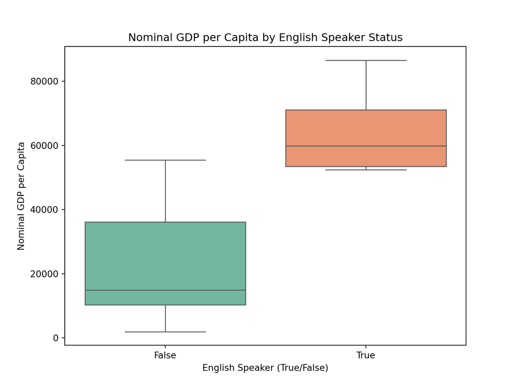

```python
plt.figure(figsize=(8,6))
sns.boxplot(x="English_Speaker", y="Nom_GDP_Per_capita", data=df, palette="Set2")
plt.title("Nominal GDP per Capita by English Speaker Status")
plt.xlabel("English Speaker (True/False)")
plt.ylabel("Nominal GDP per Capita")
plt.show()
```

## 5. Research Questions and Analysis

For example, let’s compare the average Nominal GDP per Capita for English-Speaking vs. Non-English-Speaking countries.

```python
group_summary = df.groupby("English_Speaker")["Nom_GDP_Per_capita"].mean()
print("\nAverage Nominal GDP per Capita by English Speaker status:")
```

```
##
## Average Nominal GDP per Capita by English Speaker status:
```

```python
print(group_summary)
```

```
## English_Speaker
## False    22688.941176
## True     64706.000000
## Name: Nom_GDP_Per_capita, dtype: float64
```

# Defining and Answering Research Questions

Students should define one or more research questions such as:

- **RQ1:** How does Nominal GDP per Capita differ between English-speaking and non-English-speaking G20 countries?
- **RQ2:** What is the relationship between the Human Development Index (HDI) and Nominal GDP per Capita among G20 countries?
- **RQ3:** How do emerging economies differ from advanced economies on key economic indicators?

Based on your chosen research question(s), use techniques such as group-by comparisons, correlation analysis, regression, or hypothesis testing to explore the data and draw conclusions.

# Conclusion

In your final report, include:

- A brief introduction to the G20 and dataset description.
- Details on data cleaning and variable creation.
- Descriptive statistics and visualizations addressing your research question(s).
- A discussion of your findings and conclusions.